# Telecom Churn - Ensemble Technique Project

### Domain:

- Telecom

### Context:

- A telecom company wants to use their historical customer data to predict behaviour to retain customers. You can analyse all relevant customer data and develop focused customer retention programs.

### Attribute Information:

- **CustomerID**: This column is a unique identifier for each row. It helps to identify each client of the telecom company.
- **gender**: The sex of the person. Male or Female.
- **SeniorCitizen**: If the person falls in the senior citizen category or no. 1 being yes and 0 being a no
- **Partner**: If the client has a partner. A husband or a wife, or just a partner also.
- **Dependents**: If the client has any dependents, like children, old parents and grandparents. Basically those who do not earn in the family.
- **tenure**: For how long the client has used the telecom service.
- **PhoneService**: Does the client has the phone service - yes or no .
- **MultipleLines**: Does the client have multiple lines service - yes or no or no such service exist.
- **InternetService**: Does the client have internet service - yes or no or no such service exist.
- **OnlineSecurity**: Does the client have online security service - yes or no or no such service exist.
- **OnlineBackup**: Does the client have online backup service - yes or no or no such service exist.
- **DeviceProtection**: Does the client have Device Protection service - yes or no or no such service exist.
- **TechSupport**: Does the client have Technical Support service - yes or no or no such service exist.
- **StreamingTV**: Does the client have Television Streaming service - yes or no or no such service exist.
- **StreamingMovies**: Does the client have Movies Streaming service - yes or no or no such service exist.
- **Contract**: How does the client pay the bill? Monthly, once in a year or one in two years
- **PaperlessBilling**: Does the client use paperless billing - yes or no
- **PaymentMethod**: How does the client pay the bill? via electronic check, mail check, bank transfer (automatic), credit card (automatic)
- **MonthlyCharges**: How much does the client bill comes out to be on a monthly basis.
- **TotalCharges**: How much does the client pay (incl. taxes)
- **Churn**: Customers who left within the last month

### Learning Outcomes:

- EDA.
- Splitiing Datasets into Training and Testing set.
- Bulding Models.
- Comparing Models based on their accuracy. precision, recall and F1-score.
- Pickle-ing the model.
- Making a GUI for the model.

```python
#importing basic libraries for reading the files, manipulating the files and visualization.
import pandas as pd
import numpy as np
import matplotlib.pyplot as plt
%matplotlib inline
import seaborn as sns
```

## Reading the file:

```python
churn = pd.read_csv('TelcomCustomer-Churn.csv')
```

```python
churn.head()
```

|  | customerID | gender | SeniorCitizen | Partner | Dependents | tenure | PhoneService | MultipleLines | InternetService | OnlineSecurity | ... | DeviceProtection | TechSupport | StreamingTV | StreamingMovies | Contract | PaperlessBilling | PaymentMethod | MonthlyCharges | TotalCharges | Churn |
| --- | --- | --- | --- | --- | --- | --- | --- | --- | --- | --- | --- | --- | --- | --- | --- | --- | --- | --- | --- | --- | --- |
| 0 | 7590-VHVEG | Female | 0 | Yes | No | 1 | No | No phone service | DSL | No | ... | No | No | No | No | Month-to-month | Yes | Electronic check | 29.85 | 29.85 | No |
| 1 | 5575-GNVDE | Male | 0 | No | No | 34 | Yes | No | DSL | Yes | ... | Yes | No | No | No | One year | No | Mailed check | 56.95 | 1889.5 | No |
| 2 | 3668-QPYBK | Male | 0 | No | No | 2 | Yes | No | DSL | Yes | ... | No | No | No | No | Month-to-month | Yes | Mailed check | 53.85 | 108.15 | Yes |
| 3 | 7795-CFOCW | Male | 0 | No | No | 45 | No | No phone service | DSL | Yes | ... | Yes | Yes | No | No | One year | No | Bank transfer (automatic) | 42.30 | 1840.75 | No |
| 4 | 9237-HQITU | Female | 0 | No | No | 2 | Yes | No | Fiber optic | No | ... | No | No | No | No | Month-to-month | Yes | Electronic check | 70.70 | 151.65 | Yes |

5 rows × 21 columns

```python
churn.shape
```

```
(7043, 21)
```

### We now know the file has 21 columns and 7043 rows

```python
churn.info()
```

```
<class 'pandas.core.frame.DataFrame'>
RangeIndex: 7043 entries, 0 to 7042
Data columns (total 21 columns):
 #   Column            Non-Null Count  Dtype
---  ------            --------------  -----
 0   customerID        7043 non-null   object
 1   gender            7043 non-null   object
 2   SeniorCitizen     7043 non-null   int64
 3   Partner           7043 non-null   object
 4   Dependents        7043 non-null   object
 5   tenure            7043 non-null   int64
 6   PhoneService      7043 non-null   object
 7   MultipleLines     7043 non-null   object
 8   InternetService   7043 non-null   object
 9   OnlineSecurity    7043 non-null   object
 10  OnlineBackup      7043 non-null   object
 11  DeviceProtection  7043 non-null   object
 12  TechSupport       7043 non-null   object
 13  StreamingTV       7043 non-null   object
 14  StreamingMovies   7043 non-null   object
 15  Contract          7043 non-null   object
 16  PaperlessBilling  7043 non-null   object
 17  PaymentMethod     7043 non-null   object
 18  MonthlyCharges    7043 non-null   float64
 19  TotalCharges      7043 non-null   object
 20  Churn             7043 non-null   object
dtypes: float64(1), int64(2), object(18)
memory usage: 1.1+ MB
```

### We can notice that we do not have any null values. But if you notice then you see that the column 'TotalCharges' is of type object, instead it should have been of type numeric (float)

```python
churn.describe(include ='all').T
```

|  | count | unique | top | freq | mean | std | min | 25% | 50% | 75% | max |
| --- | --- | --- | --- | --- | --- | --- | --- | --- | --- | --- | --- |
| customerID | 7043 | 7043 | 7469-LKBCI | 1 | NaN | NaN | NaN | NaN | NaN | NaN | NaN |
| gender | 7043 | 2 | Male | 3555 | NaN | NaN | NaN | NaN | NaN | NaN | NaN |
| SeniorCitizen | 7043 | NaN | NaN | NaN | 0.162147 | 0.368612 | 0 | 0 | 0 | 0 | 1 |
| Partner | 7043 | 2 | No | 3641 | NaN | NaN | NaN | NaN | NaN | NaN | NaN |
| Dependents | 7043 | 2 | No | 4933 | NaN | NaN | NaN | NaN | NaN | NaN | NaN |
| tenure | 7043 | NaN | NaN | NaN | 32.3711 | 24.5595 | 0 | 9 | 29 | 55 | 72 |
| PhoneService | 7043 | 2 | Yes | 6361 | NaN | NaN | NaN | NaN | NaN | NaN | NaN |
| MultipleLines | 7043 | 3 | No | 3390 | NaN | NaN | NaN | NaN | NaN | NaN | NaN |
| InternetService | 7043 | 3 | Fiber optic | 3096 | NaN | NaN | NaN | NaN | NaN | NaN | NaN |
| OnlineSecurity | 7043 | 3 | No | 3498 | NaN | NaN | NaN | NaN | NaN | NaN | NaN |
| OnlineBackup | 7043 | 3 | No | 3088 | NaN | NaN | NaN | NaN | NaN | NaN | NaN |
| DeviceProtection | 7043 | 3 | No | 3095 | NaN | NaN | NaN | NaN | NaN | NaN | NaN |
| TechSupport | 7043 | 3 | No | 3473 | NaN | NaN | NaN | NaN | NaN | NaN | NaN |
| StreamingTV | 7043 | 3 | No | 2810 | NaN | NaN | NaN | NaN | NaN | NaN | NaN |
| StreamingMovies | 7043 | 3 | No | 2785 | NaN | NaN | NaN | NaN | NaN | NaN | NaN |
| Contract | 7043 | 3 | Month-to-month | 3875 | NaN | NaN | NaN | NaN | NaN | NaN | NaN |
| PaperlessBilling | 7043 | 2 | Yes | 4171 | NaN | NaN | NaN | NaN | NaN | NaN | NaN |
| PaymentMethod | 7043 | 4 | Electronic check | 2365 | NaN | NaN | NaN | NaN | NaN | NaN | NaN |
| MonthlyCharges | 7043 | NaN | NaN | NaN | 64.7617 | 30.09 | 18.25 | 35.5 | 70.35 | 89.85 | 118.75 |
| TotalCharges | 7043 | 6531 |  | 11 | NaN | NaN | NaN | NaN | NaN | NaN | NaN |
| Churn | 7043 | 2 | No | 5174 | NaN | NaN | NaN | NaN | NaN | NaN | NaN |

### We are dropping the column 'customerID' from the dataframe as this column is only used to identify the client. This column will not help us in identifying if the client will churn or not.

```python
churn = churn.drop('customerID', axis = 1)
```

```python
churn.TotalCharges.value_counts()
```

```
           11
20.2       11
19.75       9
19.65       8
20.05       8
           ..
2510.7      1
5464.65     1
1797.1      1
3670.5      1
743.3       1
Name: TotalCharges, Length: 6531, dtype: int64
```

### We can see in the first row that totalCharges has some empty row. Lets fill these empty rows with null values using np.nan and then later convert the column to numeric using pd.to_numeric.

```python
churn['TotalCharges'] = churn['TotalCharges'].replace(r'\s+', np.nan, regex=True)
churn['TotalCharges'] = pd.to_numeric(churn['TotalCharges'],errors='coerce')
churn.info()
```

```
<class 'pandas.core.frame.DataFrame'>
RangeIndex: 7043 entries, 0 to 7042
Data columns (total 20 columns):
 #   Column            Non-Null Count  Dtype
---  ------            --------------  -----
 0   gender            7043 non-null   object
 1   SeniorCitizen     7043 non-null   int64
 2   Partner           7043 non-null   object
 3   Dependents        7043 non-null   object
 4   tenure            7043 non-null   int64
 5   PhoneService      7043 non-null   object
 6   MultipleLines     7043 non-null   object
 7   InternetService   7043 non-null   object
 8   OnlineSecurity    7043 non-null   object
 9   OnlineBackup      7043 non-null   object
 10  DeviceProtection  7043 non-null   object
 11  TechSupport       7043 non-null   object
 12  StreamingTV       7043 non-null   object
 13  StreamingMovies   7043 non-null   object
 14  Contract          7043 non-null   object
 15  PaperlessBilling  7043 non-null   object
 16  PaymentMethod     7043 non-null   object
 17  MonthlyCharges    7043 non-null   float64
 18  TotalCharges      7032 non-null   float64
 19  Churn             7043 non-null   object
dtypes: float64(2), int64(2), object(16)
memory usage: 1.1+ MB
```

### We can notice that TotalCharges has 11 null values. Let's drop the rows with null values as this can hamper our prediction.

```python
churn = churn.dropna(axis = 0, how ='any')
```

```python
churn.info()
```

```
<class 'pandas.core.frame.DataFrame'>
Int64Index: 7032 entries, 0 to 7042
Data columns (total 20 columns):
 #   Column            Non-Null Count  Dtype
---  ------            --------------  -----
 0   gender            7032 non-null   object
 1   SeniorCitizen     7032 non-null   int64
 2   Partner           7032 non-null   object
 3   Dependents        7032 non-null   object
 4   tenure            7032 non-null   int64
 5   PhoneService      7032 non-null   object
 6   MultipleLines     7032 non-null   object
 7   InternetService   7032 non-null   object
 8   OnlineSecurity    7032 non-null   object
 9   OnlineBackup      7032 non-null   object
 10  DeviceProtection  7032 non-null   object
 11  TechSupport       7032 non-null   object
 12  StreamingTV       7032 non-null   object
 13  StreamingMovies   7032 non-null   object
 14  Contract          7032 non-null   object
 15  PaperlessBilling  7032 non-null   object
 16  PaymentMethod     7032 non-null   object
 17  MonthlyCharges    7032 non-null   float64
 18  TotalCharges      7032 non-null   float64
 19  Churn             7032 non-null   object
dtypes: float64(2), int64(2), object(16)
memory usage: 1.1+ MB
```

### We will now look at the unique values in each of these columns.

```python
for i in churn.columns:
    print("The values in ",i,":")
    print(churn[i].unique())
    print("\n")
```

```
The values in  gender :
['Female' 'Male']


The values in  SeniorCitizen :
[0 1]


The values in  Partner :
['Yes' 'No']


The values in  Dependents :
['No' 'Yes']


The values in  tenure :
[ 1 34  2 45  8 22 10 28 62 13 16 58 49 25 69 52 71 21 12 30 47 72 17 27
  5 46 11 70 63 43 15 60 18 66  9  3 31 50 64 56  7 42 35 48 29 65 38 68
 32 55 37 36 41  6  4 33 67 23 57 61 14 20 53 40 59 24 44 19 54 51 26 39]


The values in  PhoneService :
['No' 'Yes']


The values in  MultipleLines :
['No phone service' 'No' 'Yes']


The values in  InternetService :
['DSL' 'Fiber optic' 'No']


The values in  OnlineSecurity :
['No' 'Yes' 'No internet service']


The values in  OnlineBackup :
['Yes' 'No' 'No internet service']
```

[output cut: 26 more lines]

```
The values in  PaymentMethod :
['Electronic check' 'Mailed check' 'Bank transfer (automatic)'
 'Credit card (automatic)']


The values in  MonthlyCharges :
[29.85 56.95 53.85 ... 63.1  44.2  78.7 ]


The values in  TotalCharges :
[  29.85 1889.5   108.15 ...  346.45  306.6  6844.5 ]


The values in  Churn :
['No' 'Yes']
```

### Checking the distribution of target variable

```python
display(churn['Churn'].value_counts(), churn['Churn'].value_counts(normalize = True)*100)
```

```
No     5163
Yes    1869
Name: Churn, dtype: int64
```

```
No     73.421502
Yes    26.578498
Name: Churn, dtype: float64
```

### We can see that 73.4% of the client have not churned, Where has 26.6% have curned.

### Lets Now replace the categorical values to numbers. Machine Learning models learn from numbers quickly.

```python
cat_cols = {'gender': {'Female': 1, 'Male': 0},
           'Partner': {'Yes': 1, 'No': 0},
           'Dependents': {'Yes': 1, 'No': 0},
           'PhoneService': {'Yes': 1, 'No': 0},
           'MultipleLines': {'No phone service': -1, 'No': 0, 'Yes': 1},
           'InternetService': {'DSL': 0, 'Fiber optic': 1, 'No': 2},
           'OnlineSecurity': {'No': 0, 'Yes': 1, 'No internet service': -1},
           'OnlineBackup': {'No': 0, 'Yes': 1, 'No internet service': -1},
           'DeviceProtection': {'No': 0, 'Yes': 1, 'No internet service': -1},
           'TechSupport': {'No': 0, 'Yes': 1, 'No internet service': -1},
           'StreamingTV': {'No': 0, 'Yes': 1, 'No internet service': -1},
           'StreamingMovies': {'No': 0, 'Yes': 1, 'No internet service': -1},
           'Contract': {'Month-to-month': 0, 'One year': 1, 'Two year': 2},
           'PaperlessBilling': {'Yes': 1, 'No': 0},
           'PaymentMethod': {'Electronic check': 1,'Mailed check':2,'Bank transfer (automatic)':3,'Credit card (automatic)':4},
           'Churn': {'Yes': 1, 'No': 0}}
churn = churn.replace(cat_cols)
```

```python
churn.head()
```

|  | gender | SeniorCitizen | Partner | Dependents | tenure | PhoneService | MultipleLines | InternetService | OnlineSecurity | OnlineBackup | DeviceProtection | TechSupport | StreamingTV | StreamingMovies | Contract | PaperlessBilling | PaymentMethod | MonthlyCharges | TotalCharges | Churn |
| --- | --- | --- | --- | --- | --- | --- | --- | --- | --- | --- | --- | --- | --- | --- | --- | --- | --- | --- | --- | --- |
| 0 | 1 | 0 | 1 | 0 | 1 | 0 | -1 | 0 | 0 | 1 | 0 | 0 | 0 | 0 | 0 | 1 | 1 | 29.85 | 29.85 | 0 |
| 1 | 0 | 0 | 0 | 0 | 34 | 1 | 0 | 0 | 1 | 0 | 1 | 0 | 0 | 0 | 1 | 0 | 2 | 56.95 | 1889.50 | 0 |
| 2 | 0 | 0 | 0 | 0 | 2 | 1 | 0 | 0 | 1 | 1 | 0 | 0 | 0 | 0 | 0 | 1 | 2 | 53.85 | 108.15 | 1 |
| 3 | 0 | 0 | 0 | 0 | 45 | 0 | -1 | 0 | 1 | 0 | 1 | 1 | 0 | 0 | 1 | 0 | 3 | 42.30 | 1840.75 | 0 |
| 4 | 1 | 0 | 0 | 0 | 2 | 1 | 0 | 1 | 0 | 0 | 0 | 0 | 0 | 0 | 0 | 1 | 1 | 70.70 | 151.65 | 1 |

```python
churn.describe().T
```

|  | count | mean | std | min | 25% | 50% | 75% | max |
| --- | --- | --- | --- | --- | --- | --- | --- | --- |
| gender | 7032.0 | 0.495307 | 0.500014 | 0.00 | 0.0000 | 0.000 | 1.0000 | 1.00 |
| SeniorCitizen | 7032.0 | 0.162400 | 0.368844 | 0.00 | 0.0000 | 0.000 | 0.0000 | 1.00 |
| Partner | 7032.0 | 0.482509 | 0.499729 | 0.00 | 0.0000 | 0.000 | 1.0000 | 1.00 |
| Dependents | 7032.0 | 0.298493 | 0.457629 | 0.00 | 0.0000 | 0.000 | 1.0000 | 1.00 |
| tenure | 7032.0 | 32.421786 | 24.545260 | 1.00 | 9.0000 | 29.000 | 55.0000 | 72.00 |
| PhoneService | 7032.0 | 0.903299 | 0.295571 | 0.00 | 1.0000 | 1.000 | 1.0000 | 1.00 |
| MultipleLines | 7032.0 | 0.325228 | 0.642585 | -1.00 | 0.0000 | 0.000 | 1.0000 | 1.00 |
| InternetService | 7032.0 | 0.872582 | 0.737271 | 0.00 | 0.0000 | 1.000 | 1.0000 | 2.00 |
| OnlineSecurity | 7032.0 | 0.070392 | 0.705562 | -1.00 | 0.0000 | 0.000 | 1.0000 | 1.00 |
| OnlineBackup | 7032.0 | 0.128697 | 0.737917 | -1.00 | 0.0000 | 0.000 | 1.0000 | 1.00 |
| DeviceProtection | 7032.0 | 0.127702 | 0.737415 | -1.00 | 0.0000 | 0.000 | 1.0000 | 1.00 |
| TechSupport | 7032.0 | 0.073948 | 0.707715 | -1.00 | 0.0000 | 0.000 | 1.0000 | 1.00 |
| StreamingTV | 7032.0 | 0.168231 | 0.756518 | -1.00 | 0.0000 | 0.000 | 1.0000 | 1.00 |
| StreamingMovies | 7032.0 | 0.172213 | 0.758252 | -1.00 | 0.0000 | 0.000 | 1.0000 | 1.00 |
| Contract | 7032.0 | 0.688567 | 0.832934 | 0.00 | 0.0000 | 0.000 | 1.0000 | 2.00 |
| PaperlessBilling | 7032.0 | 0.592719 | 0.491363 | 0.00 | 0.0000 | 1.000 | 1.0000 | 1.00 |
| PaymentMethod | 7032.0 | 2.315557 | 1.149523 | 1.00 | 1.0000 | 2.000 | 3.0000 | 4.00 |
| MonthlyCharges | 7032.0 | 64.798208 | 30.085974 | 18.25 | 35.5875 | 70.350 | 89.8625 | 118.75 |
| TotalCharges | 7032.0 | 2283.300441 | 2266.771362 | 18.80 | 401.4500 | 1397.475 | 3794.7375 | 8684.80 |
| Churn | 7032.0 | 0.265785 | 0.441782 | 0.00 | 0.0000 | 0.000 | 1.0000 | 1.00 |

### From the above description of the data, let's look into the columns:

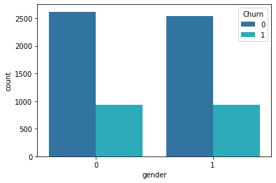

```python
sns.countplot('gender', data = churn, palette = ['tab:blue', 'tab:cyan'], orient = 'v',hue = 'Churn');
```

#### In the above graph, Gender: 0=Male, 1=Female.

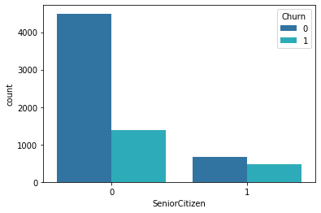

```python
sns.countplot('SeniorCitizen', data = churn, palette = ['tab:blue', 'tab:cyan'], orient = 'v',hue = 'Churn');
```

### From the above plot we can see that the number of clients who are not senior citizens is way larger than the ones who are.

#### From the above graph. SeniorCitizen: 0= Not a Senior Citizen, 1=Yes, a senior citizen.

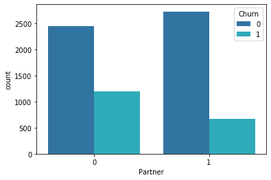

```python
sns.countplot('Partner', data = churn, palette = ['tab:blue', 'tab:cyan'], orient = 'v',hue = 'Churn');
```

### From the above graph we can see that having a partner affects ones behaviour towards changing their telecom company. Clients who have partners (1) have a very small fraction of churning than the ones who do have a partner(0).

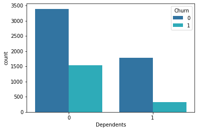

```python
sns.countplot('Dependents', data = churn, palette = ['tab:blue', 'tab:cyan'], orient = 'v',hue = 'Churn');
```

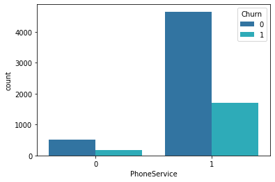

```python
sns.countplot('PhoneService', data = churn, palette = ['tab:blue', 'tab:cyan'], orient = 'v',hue = 'Churn');
```

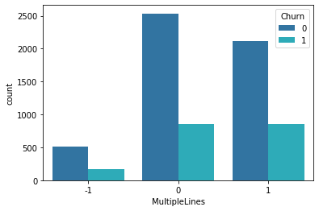

```python
sns.countplot('MultipleLines', data = churn, palette = ['tab:blue', 'tab:cyan'], orient = 'v',hue = 'Churn');
```

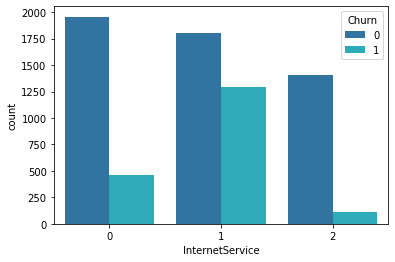

```python
sns.countplot('InternetService', data = churn, palette = ['tab:blue', 'tab:cyan'], orient = 'v',hue = 'Churn');
```

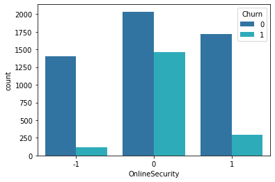

```python
sns.countplot('OnlineSecurity', data = churn, palette = ['tab:blue', 'tab:cyan'], orient = 'v',hue = 'Churn');
```

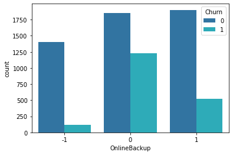

```python
sns.countplot('OnlineBackup', data = churn, palette = ['tab:blue', 'tab:cyan'], orient = 'v',hue = 'Churn');
```

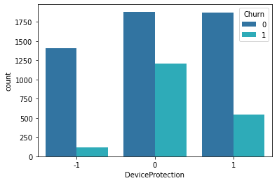

```python
sns.countplot('DeviceProtection', data = churn, palette = ['tab:blue', 'tab:cyan'], orient = 'v',hue = 'Churn');
```

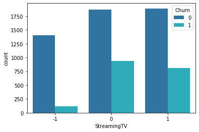

```python
sns.countplot('StreamingTV', data = churn, palette = ['tab:blue', 'tab:cyan'], orient = 'v',hue = 'Churn');
```

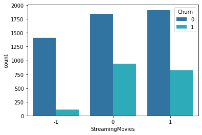

```python
sns.countplot('StreamingMovies', data = churn, palette = ['tab:blue', 'tab:cyan'], orient = 'v',hue = 'Churn');
```

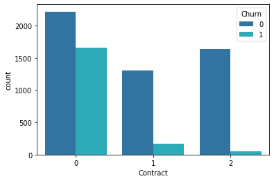

```python
sns.countplot('Contract', data = churn, palette = ['tab:blue', 'tab:cyan'], orient = 'v',hue = 'Churn');
```

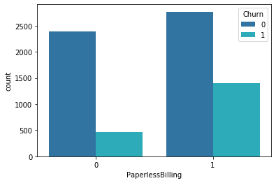

```python
sns.countplot('PaperlessBilling', data = churn, palette = ['tab:blue', 'tab:cyan'], orient = 'v',hue = 'Churn');
```

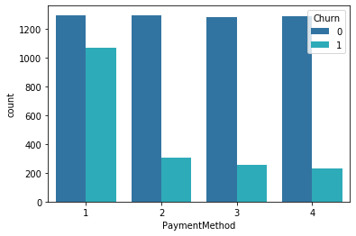

```python
sns.countplot('PaymentMethod', data = churn, palette = ['tab:blue', 'tab:cyan'], orient = 'v',hue = 'Churn');
```

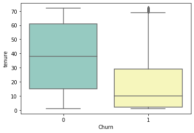

```python
sns.boxplot( churn['Churn'], churn['tenure'],orient = 'v',palette="Set3");
```

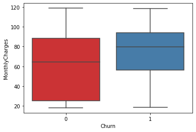

```python
sns.boxplot( churn['Churn'], churn['MonthlyCharges'],orient = 'v',palette="Set1");
```

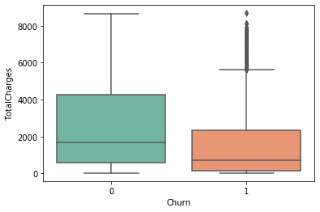

```python
sns.boxplot( churn['Churn'],churn['TotalCharges'],orient = 'v',palette="Set2");
```

### Let's check the correlation of each column with one another:

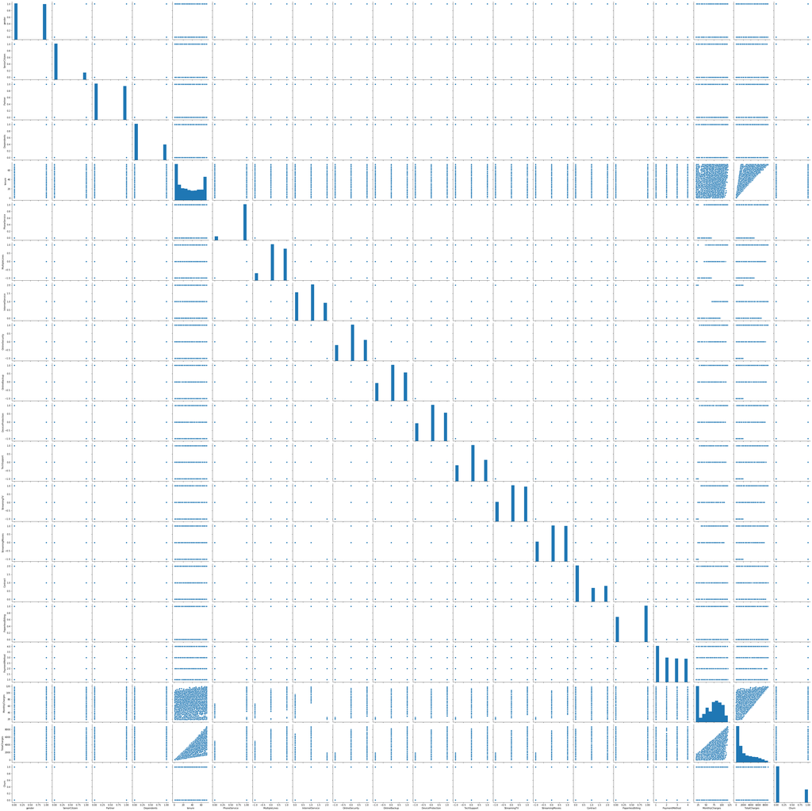

```python
sns.pairplot(churn)
```

```python
churn.corr()
```

|  | gender | SeniorCitizen | Partner | Dependents | tenure | PhoneService | MultipleLines | InternetService | OnlineSecurity | OnlineBackup | DeviceProtection | TechSupport | StreamingTV | StreamingMovies | Contract | PaperlessBilling | PaymentMethod | MonthlyCharges | TotalCharges | Churn |
| --- | --- | --- | --- | --- | --- | --- | --- | --- | --- | --- | --- | --- | --- | --- | --- | --- | --- | --- | --- | --- |
| gender | 1.000000 | 0.001819 | 0.001379 | -0.010349 | -0.005285 | 0.007515 | 0.010284 | 0.002236 | 0.013233 | 0.011081 | 0.003168 | 0.008215 | 0.007163 | 0.009072 | -0.000095 | 0.011902 | 0.004928 | 0.013779 | -0.000048 | 0.008545 |
| SeniorCitizen | 0.001819 | 1.000000 | 0.016957 | -0.210550 | 0.015683 | 0.008392 | 0.113769 | -0.032160 | 0.081766 | 0.144762 | 0.140226 | 0.067318 | 0.167123 | 0.176125 | -0.141820 | 0.156258 | -0.093712 | 0.219874 | 0.102411 | 0.150541 |
| Partner | 0.001379 | 0.016957 | 1.000000 | 0.452269 | 0.381912 | 0.018397 | 0.118037 | 0.000513 | 0.092034 | 0.091536 | 0.099077 | 0.077252 | 0.080205 | 0.076076 | 0.294094 | -0.013957 | 0.133280 | 0.097825 | 0.319072 | -0.149982 |
| Dependents | -0.010349 | -0.210550 | 0.452269 | 1.000000 | 0.163386 | -0.001078 | -0.019178 | 0.044030 | -0.028964 | -0.061970 | -0.068296 | -0.040057 | -0.085909 | -0.099795 | 0.240556 | -0.110131 | 0.124002 | -0.112343 | 0.064653 | -0.163128 |
| tenure | -0.005285 | 0.015683 | 0.381912 | 0.163386 | 1.000000 | 0.007877 | 0.259112 | -0.029835 | 0.232295 | 0.253575 | 0.253834 | 0.230429 | 0.200646 | 0.203834 | 0.676734 | 0.004823 | 0.340939 | 0.246862 | 0.825880 | -0.354049 |
| PhoneService | 0.007515 | 0.008392 | 0.018397 | -0.001078 | 0.007877 | 1.000000 | 0.674824 | 0.387266 | -0.158997 | -0.129432 | -0.141055 | -0.160950 | -0.107242 | -0.114798 | 0.003019 | 0.016696 | -0.003106 | 0.248033 | 0.113008 | 0.011691 |
| MultipleLines | 0.010284 | 0.113769 | 0.118037 | -0.019178 | 0.259112 | 0.674824 | 1.000000 | 0.186852 | 0.069959 | 0.130978 | 0.125447 | 0.069706 | 0.166256 | 0.163218 | 0.084037 | 0.133538 | 0.026248 | 0.491412 | 0.412495 | 0.036148 |
| InternetService | 0.002236 | -0.032160 | 0.000513 | 0.044030 | -0.029835 | 0.387266 | 0.186852 | 1.000000 | -0.719879 | -0.650084 | -0.645266 | -0.716276 | -0.592172 | -0.596779 | 0.099579 | -0.138166 | 0.008851 | -0.322173 | -0.175691 | -0.047097 |
| OnlineSecurity | 0.013233 | 0.081766 | 0.092034 | -0.028964 | 0.232295 | -0.158997 | 0.069959 | -0.719879 | 1.000000 | 0.704598 | 0.701112 | 0.734696 | 0.661541 | 0.666682 | 0.016495 | 0.184449 | 0.035563 | 0.635260 | 0.483157 | 0.023014 |
| OnlineBackup | 0.011081 | 0.144762 | 0.091536 | -0.061970 | 0.253575 | -0.129432 | 0.130978 | -0.650084 | 0.704598 | 1.000000 | 0.710790 | 0.708659 | 0.702605 | 0.699828 | -0.034745 | 0.260691 | -0.003786 | 0.710175 | 0.537726 | 0.073934 |
| DeviceProtection | 0.003168 | 0.140226 | 0.099077 | -0.068296 | 0.253834 | -0.141055 | 0.125447 | -0.645266 | 0.701112 | 0.710790 | 1.000000 | 0.724817 | 0.747489 | 0.752755 | 0.006638 | 0.246011 | 0.005643 | 0.736925 | 0.546100 | 0.084402 |
| TechSupport | 0.008215 | 0.067318 | 0.077252 | -0.040057 | 0.230429 | -0.160950 | 0.069706 | -0.716276 | 0.734696 | 0.708659 | 0.724817 | 1.000000 | 0.703306 | 0.704595 | 0.048001 | 0.210547 | 0.038621 | 0.660864 | 0.495641 | 0.026744 |
| StreamingTV | 0.007163 | 0.167123 | 0.080205 | -0.085909 | 0.200646 | -0.107242 | 0.166256 | -0.592172 | 0.661541 | 0.702605 | 0.747489 | 0.703306 | 1.000000 | 0.807118 | -0.064457 | 0.318646 | -0.073319 | 0.820193 | 0.535616 | 0.164509 |
| StreamingMovies | 0.009072 | 0.176125 | 0.076076 | -0.099795 | 0.203834 | -0.114798 | 0.163218 | -0.596779 | 0.666682 | 0.699828 | 0.752755 | 0.704595 | 0.807118 | 1.000000 | -0.060995 | 0.310055 | -0.066761 | 0.817525 | 0.537695 | 0.162672 |
| Contract | -0.000095 | -0.141820 | 0.294094 | 0.240556 | 0.676734 | 0.003019 | 0.084037 | 0.099579 | 0.016495 | -0.034745 | 0.006638 | 0.048001 | -0.064457 | -0.060995 | 1.000000 | -0.175475 | 0.359487 | -0.072739 | 0.450306 | -0.396150 |
| PaperlessBilling | 0.011902 | 0.156258 | -0.013957 | -0.110131 | 0.004823 | 0.016696 | 0.133538 | -0.138166 | 0.184449 | 0.260691 | 0.246011 | 0.210547 | 0.318646 | 0.310055 | -0.175475 | 1.000000 | -0.101790 | 0.351930 | 0.157830 | 0.191454 |
| PaymentMethod | 0.004928 | -0.093712 | 0.133280 | 0.124002 | 0.340939 | -0.003106 | 0.026248 | 0.008851 | 0.035563 | -0.003786 | 0.005643 | 0.038621 | -0.073319 | -0.066761 | 0.359487 | -0.101790 | 1.000000 | -0.074640 | 0.222694 | -0.262918 |
| MonthlyCharges | 0.013779 | 0.219874 | 0.097825 | -0.112343 | 0.246862 | 0.248033 | 0.491412 | -0.322173 | 0.635260 | 0.710175 | 0.736925 | 0.660864 | 0.820193 | 0.817525 | -0.072739 | 0.351930 | -0.074640 | 1.000000 | 0.651065 | 0.192858 |
| TotalCharges | -0.000048 | 0.102411 | 0.319072 | 0.064653 | 0.825880 | 0.113008 | 0.412495 | -0.175691 | 0.483157 | 0.537726 | 0.546100 | 0.495641 | 0.535616 | 0.537695 | 0.450306 | 0.157830 | 0.222694 | 0.651065 | 1.000000 | -0.199484 |
| Churn | 0.008545 | 0.150541 | -0.149982 | -0.163128 | -0.354049 | 0.011691 | 0.036148 | -0.047097 | 0.023014 | 0.073934 | 0.084402 | 0.026744 | 0.164509 | 0.162672 | -0.396150 | 0.191454 | -0.262918 | 0.192858 | -0.199484 | 1.000000 |

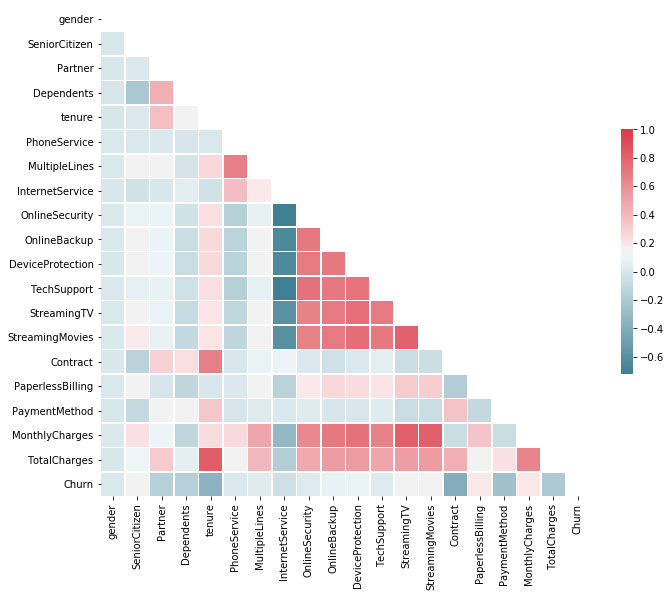

```python
corr = churn.corr()

mask = np.zeros_like(corr, dtype = np.bool)
mask[np.triu_indices_from(mask)] = True

f, ax = plt.subplots(figsize = (11, 9))

cmap = sns.diverging_palette(220, 10, as_cmap = True)

sns.heatmap(corr, mask = mask, cmap = cmap, square = True, linewidths = .5, cbar_kws = {"shrink": .5});
```

### Checking the Correlation of all the features with the target column:

```python
churn_corr = []
indp_cols = churn.drop('Churn', axis = 1).columns

for cols in indp_cols:
    churn_corr.append(churn['Churn'].corr(churn[cols]))

display(pd.DataFrame([indp_cols, churn_corr], index = ['Column Names', 'Correlation with Churn']).T.sort_values('Correlation with Churn', ascending = False))
```

|  | Column Names | Correlation with Churn |
| --- | --- | --- |
| 17 | MonthlyCharges | 0.192858 |
| 15 | PaperlessBilling | 0.191454 |
| 12 | StreamingTV | 0.164509 |
| 13 | StreamingMovies | 0.162672 |
| 1 | SeniorCitizen | 0.150541 |
| 10 | DeviceProtection | 0.0844017 |
| 9 | OnlineBackup | 0.0739344 |
| 6 | MultipleLines | 0.0361476 |
| 11 | TechSupport | 0.0267445 |
| 8 | OnlineSecurity | 0.0230136 |
| 5 | PhoneService | 0.0116914 |
| 0 | gender | 0.00854464 |
| 7 | InternetService | -0.0470972 |
| 2 | Partner | -0.149982 |
| 3 | Dependents | -0.163128 |
| 18 | TotalCharges | -0.199484 |
| 16 | PaymentMethod | -0.262918 |
| 4 | tenure | -0.354049 |
| 14 | Contract | -0.39615 |

## Modelling:

- Logistic Regression
- K- Nearest Neighbor
- Naive Bayes
- Support Vector Machine
- Decision Tree Classifier
- Bagging Classifier
- Adaboost
- Gradient Boosting Classifier
- Random Forest Classifier

```python
# importing all the necessary modules for modelling

from sklearn.metrics import classification_report, confusion_matrix, accuracy_score, f1_score, recall_score, precision_score
from sklearn.ensemble import GradientBoostingClassifier, RandomForestClassifier, BaggingClassifier, VotingClassifier
from sklearn.model_selection import train_test_split, GridSearchCV, StratifiedKFold, cross_val_score
from sklearn.linear_model import LogisticRegression
from sklearn.neighbors import KNeighborsClassifier
from sklearn.ensemble import AdaBoostClassifier
from sklearn.tree import DecisionTreeClassifier
from sklearn.naive_bayes import GaussianNB
from sklearn.metrics import make_scorer
from sklearn.tree import export_graphviz
from IPython.display import Image
from os import system
from scipy.stats import zscore, norm, randint
```

### Scaling the feature columns to make it easier to calculation the precision, recall and the F-1 score.

```python
from sklearn.preprocessing import RobustScaler
X = churn.drop(['Churn'], axis = 1)
y = churn['Churn']

# Applying RobustScaler to make it less prone to outliers
features = X.columns
scaler = RobustScaler()
X = pd.DataFrame(scaler.fit_transform(X), columns = features)

# Scaling the independent variables
Xs = X.apply(zscore)

display(X.shape, Xs.shape, y.shape)
X_train, X_test, y_train, y_test = train_test_split(X, y, test_size = 0.3, random_state = 42)
```

```
(7032, 19)
```

```
(7032, 19)
```

```
(7032,)
```

### Logistic Regression

```python
LR = LogisticRegression(solver="liblinear")
model_lr = LR.fit(X_train, y_train)
y_pred = LR.predict(X_test)

accuracy_ = accuracy_score(y_test, y_pred)
precision_lr = precision_score(y_test, y_pred)
recall_lr = recall_score(y_test, y_pred)
f1_score_lr = 2 * (precision_lr * recall_lr) / (precision_lr + recall_lr)
print('Training Score: ', LR.score(X_train, y_train).round(3))
print('Test Score: ', LR.score(X_test, y_test).round(3))
print('Precision Score: ', precision_lr.round(3))
print('Recall Score: ', recall_lr.round(3))
print('f1 Score: ', f1_score_lr.round(3))

df = pd.DataFrame([accuracy_.round(3), precision_lr.round(3), recall_lr.round(3), f1_score_lr.round(3)],
                  columns = ['Logistic Regression Model']).T
df.columns = ['Accuracy', 'Precision', 'Recall', 'f1']
df
```

```
Training Score:  0.805
Test Score:  0.792
Precision Score:  0.635
Recall Score:  0.517
f1 Score:  0.57
```

|  | Accuracy | Precision | Recall | f1 |
| --- | --- | --- | --- | --- |
| Logistic Regression Model | 0.792 | 0.635 | 0.517 | 0.57 |

### K-NN

```python
kNN = KNeighborsClassifier(n_neighbors= 7, weights = 'distance')
model_knn = kNN.fit(X_train, y_train)
y_pred = kNN.predict(X_test)

accuracy_ = accuracy_score(y_test, y_pred)
precision_knn = precision_score(y_test, y_pred)
recall_knn = recall_score(y_test, y_pred)
f1_score_knn= f1_score(y_test, y_pred)
print('Training Score: ', kNN.score(X_train, y_train).round(3))
print('Test Score: ', kNN.score(X_test, y_test).round(3))
print('Precision Score: ', precision_knn.round(3))
print('Recall Score: ', recall_knn.round(3))
print('f1 Score: ', f1_score_knn.round(3))

df1 = pd.DataFrame([accuracy_.round(3), precision_knn.round(3), recall_knn.round(3), f1_score_knn.round(3)],
                  columns = ['K-NN Model']).T
df1.columns = ['Accuracy', 'Precision', 'Recall', 'f1']
df1
```

```
Training Score:  0.999
Test Score:  0.757
Precision Score:  0.549
Recall Score:  0.488
f1 Score:  0.517
```

|  | Accuracy | Precision | Recall | f1 |
| --- | --- | --- | --- | --- |
| K-NN Model | 0.757 | 0.549 | 0.488 | 0.517 |

### Comparing the models

```python
model = df.append(df1)
model
```

|  | Accuracy | Precision | Recall | f1 |
| --- | --- | --- | --- | --- |
| Logistic Regression Model | 0.792 | 0.635 | 0.517 | 0.570 |
| K-NN Model | 0.757 | 0.549 | 0.488 | 0.517 |

### Naive Bayes:

```python
NB = GaussianNB()
model_nb=NB.fit(X_train, y_train)
y_pred = NB.predict(X_test)

accuracy_ = accuracy_score(y_test, y_pred)
precision_nb = precision_score(y_test, y_pred)
recall_nb = recall_score(y_test, y_pred)
f1_score_nb = f1_score(y_test, y_pred)
print('Training Score: ', NB.score(X_train, y_train).round(3))
print('Test Score: ', NB.score(X_test, y_test).round(3))
print('Precision Score: ', precision_nb.round(3))
print('Recall Score: ', recall_nb.round(3))
print('f1 Score: ', f1_score_nb.round(3))

df2 = pd.DataFrame([accuracy_.round(3), precision_nb.round(3), recall_nb.round(3), f1_score_nb.round(3)],
                  columns = ['Naive Bayes Model']).T
df2.columns = ['Accuracy', 'Precision', 'Recall', 'f1']
df2
```

```
Training Score:  0.734
Test Score:  0.728
Precision Score:  0.493
Recall Score:  0.786
f1 Score:  0.606
```

|  | Accuracy | Precision | Recall | f1 |
| --- | --- | --- | --- | --- |
| Naive Bayes Model | 0.728 | 0.493 | 0.786 | 0.606 |

### Comparing the models

```python
model = model.append(df2)
model
```

|  | Accuracy | Precision | Recall | f1 |
| --- | --- | --- | --- | --- |
| Logistic Regression Model | 0.792 | 0.635 | 0.517 | 0.570 |
| K-NN Model | 0.757 | 0.549 | 0.488 | 0.517 |
| Naive Bayes Model | 0.728 | 0.493 | 0.786 | 0.606 |

### Support Vector Machine:

```python
from sklearn.svm import SVC
SV= SVC(gamma=0.025, C=3)
model_sv=SV.fit(X_train, y_train)
y_pred = SV.predict(X_test)

accuracy_ = accuracy_score(y_test, y_pred)
precision_sv = precision_score(y_test, y_pred)
recall_sv = recall_score(y_test, y_pred)
f1_score_sv = f1_score(y_test, y_pred)
print('Training Score: ', SV.score(X_train, y_train).round(3))
print('Test Score: ', SV.score(X_test, y_test).round(3))
print('Precision Score: ', precision_sv.round(3))
print('Recall Score: ', recall_sv.round(3))
print('f1 Score: ', f1_score_sv.round(3))

df3 = pd.DataFrame([accuracy_.round(3), precision_sv.round(3), recall_sv.round(3), f1_score_sv.round(3)],
                  columns = ['SVM Model']).T
df3.columns = ['Accuracy', 'Precision', 'Recall', 'f1']
df3
```

```
Training Score:  0.803
Test Score:  0.793
Precision Score:  0.652
Recall Score:  0.474
f1 Score:  0.549
```

|  | Accuracy | Precision | Recall | f1 |
| --- | --- | --- | --- | --- |
| SVM Model | 0.793 | 0.652 | 0.474 | 0.549 |

### Comparing the models

```python
model = model.append(df3)
model
```

|  | Accuracy | Precision | Recall | f1 |
| --- | --- | --- | --- | --- |
| Logistic Regression Model | 0.792 | 0.635 | 0.517 | 0.570 |
| K-NN Model | 0.757 | 0.549 | 0.488 | 0.517 |
| Naive Bayes Model | 0.728 | 0.493 | 0.786 | 0.606 |
| SVM Model | 0.793 | 0.652 | 0.474 | 0.549 |

### Decisin Tree:

```python
dTreeR = DecisionTreeClassifier(criterion = 'gini', max_depth = 3, random_state=1)
model_dtree = dTreeR.fit(X_train, y_train)
y_pred = dTreeR.predict(X_test)

accuracy_ = accuracy_score(y_test, y_pred)
precision_dtree = precision_score(y_test, y_pred)
recall_dtree = recall_score(y_test, y_pred)
f1_score_dtree = f1_score(y_test, y_pred)
print('Training Score: ', dTreeR.score(X_train, y_train).round(3))
print('Test Score: ', dTreeR.score(X_test, y_test).round(3))
print('Precision Score: ', precision_dtree.round(3))
print('Recall Score: ', recall_dtree.round(3))
print('f1 Score: ', f1_score_dtree.round(3))

df4 = pd.DataFrame([accuracy_.round(3), precision_dtree.round(3), recall_dtree.round(3), f1_score_dtree.round(3)],
                  columns = ['Decision Tree Model']).T
df4.columns = ['Accuracy', 'Precision', 'Recall', 'f1']
df4
```

```
Training Score:  0.79
Test Score:  0.777
Precision Score:  0.653
Recall Score:  0.346
f1 Score:  0.452
```

|  | Accuracy | Precision | Recall | f1 |
| --- | --- | --- | --- | --- |
| Decision Tree Model | 0.777 | 0.653 | 0.346 | 0.452 |

### Plotting The Decision Tree:

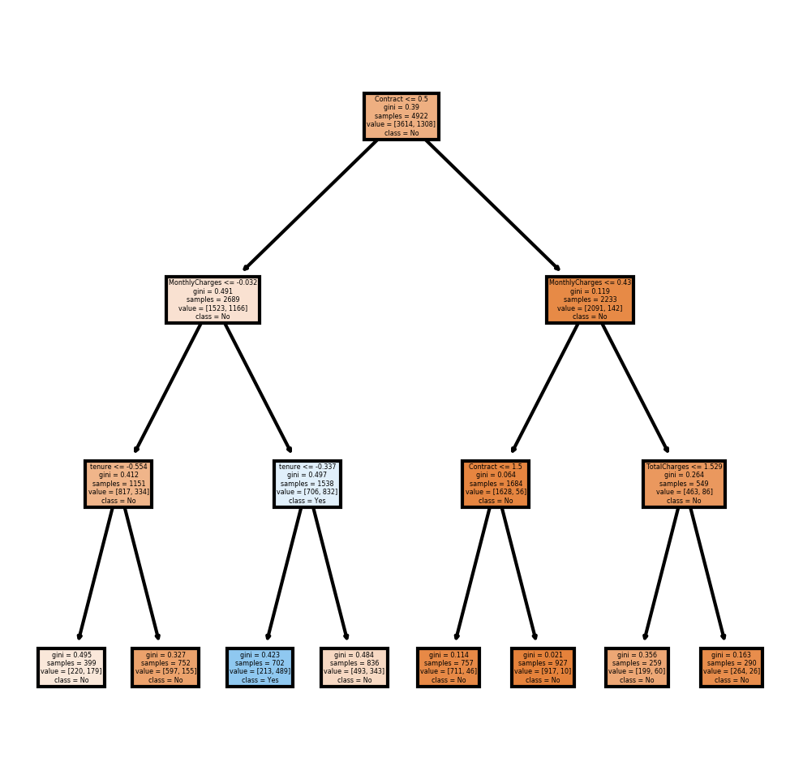

```python
from sklearn.tree import plot_tree

fn = list(X_train)
cn = ['No', 'Yes']
fig, axes = plt.subplots(nrows = 1,ncols = 1,figsize = (4, 4), dpi=300)
plot_tree(dTreeR, feature_names = fn, class_names=cn, filled = True)

fig.savefig('tree.png')
```

### Features that impacted the decision tree built:

```python
print (pd.DataFrame(dTreeR.feature_importances_, columns = ["Imp"], index = X_train.columns))
```

```
                       Imp
gender            0.000000
SeniorCitizen     0.000000
Partner           0.000000
Dependents        0.000000
tenure            0.175776
PhoneService      0.000000
MultipleLines     0.000000
InternetService   0.000000
OnlineSecurity    0.000000
OnlineBackup      0.000000
DeviceProtection  0.000000
TechSupport       0.000000
StreamingTV       0.000000
StreamingMovies   0.000000
Contract          0.633894
PaperlessBilling  0.000000
PaymentMethod     0.000000
MonthlyCharges    0.179925
TotalCharges      0.010405
```

### Comparing the models:

```python
model = model.append(df4)
model
```

|  | Accuracy | Precision | Recall | f1 |
| --- | --- | --- | --- | --- |
| Logistic Regression Model | 0.792 | 0.635 | 0.517 | 0.570 |
| K-NN Model | 0.757 | 0.549 | 0.488 | 0.517 |
| Naive Bayes Model | 0.728 | 0.493 | 0.786 | 0.606 |
| SVM Model | 0.793 | 0.652 | 0.474 | 0.549 |
| Decision Tree Model | 0.777 | 0.653 | 0.346 | 0.452 |

### Bagging Classifier:

```python
bgcl = BaggingClassifier(base_estimator=dTreeR, n_estimators=50,random_state=1)
model_bgcl = bgcl.fit(X_train, y_train)
y_pred = bgcl.predict(X_test)

accuracy_ = accuracy_score(y_test, y_pred)
precision_bgcl = precision_score(y_test, y_pred)
recall_bgcl = recall_score(y_test, y_pred)
f1_score_bgcl = f1_score(y_test, y_pred)
print('Training Score: ', bgcl.score(X_train, y_train).round(3))
print('Test Score: ', bgcl.score(X_test, y_test).round(3))
print('Precision Score: ', precision_bgcl.round(3))
print('Recall Score: ', recall_bgcl.round(3))
print('f1 Score: ', f1_score_bgcl.round(3))

df5 = pd.DataFrame([accuracy_.round(3), precision_bgcl.round(3), recall_bgcl.round(3), f1_score_bgcl.round(3)],
                  columns = ['Bagging Classifier Model']).T
df5.columns = ['Accuracy', 'Precision', 'Recall', 'f1']
df5
```

```
Training Score:  0.791
Test Score:  0.778
Precision Score:  0.651
Recall Score:  0.357
f1 Score:  0.461
```

|  | Accuracy | Precision | Recall | f1 |
| --- | --- | --- | --- | --- |
| Bagging Classifier Model | 0.778 | 0.651 | 0.357 | 0.461 |

### Comparing the models:

```python
model = model.append(df5)
model
```

|  | Accuracy | Precision | Recall | f1 |
| --- | --- | --- | --- | --- |
| Logistic Regression Model | 0.792 | 0.635 | 0.517 | 0.570 |
| K-NN Model | 0.757 | 0.549 | 0.488 | 0.517 |
| Naive Bayes Model | 0.728 | 0.493 | 0.786 | 0.606 |
| SVM Model | 0.793 | 0.652 | 0.474 | 0.549 |
| Decision Tree Model | 0.777 | 0.653 | 0.346 | 0.452 |
| Bagging Classifier Model | 0.778 | 0.651 | 0.357 | 0.461 |

### AdaBoost Classifier:

```python
abcl = AdaBoostClassifier(n_estimators=10, random_state=1)
model_abcl = abcl.fit(X_train, y_train)
y_pred = abcl.predict(X_test)

accuracy_ = accuracy_score(y_test, y_pred)
precision_abcl = precision_score(y_test, y_pred)
recall_abcl = recall_score(y_test, y_pred)
f1_score_abcl = f1_score(y_test, y_pred)
print('Training Score: ', abcl.score(X_train, y_train).round(3))
print('Test Score: ', abcl.score(X_test, y_test).round(3))
print('Precision Score: ', precision_abcl.round(3))
print('Recall Score: ', recall_abcl.round(3))
print('f1 Score: ', f1_score_abcl.round(3))

df6 = pd.DataFrame([accuracy_.round(3), precision_abcl.round(3), recall_abcl.round(3), f1_score_abcl.round(3)],
                  columns = ['Ada Boosting Classifier Model']).T
df6.columns = ['Accuracy', 'Precision', 'Recall', 'f1']
df6
```

```
Training Score:  0.796
Test Score:  0.786
Precision Score:  0.614
Recall Score:  0.524
f1 Score:  0.565
```

|  | Accuracy | Precision | Recall | f1 |
| --- | --- | --- | --- | --- |
| Ada Boosting Classifier Model | 0.786 | 0.614 | 0.524 | 0.565 |

### Comparing the models:

```python
model = model.append(df6)
model
```

|  | Accuracy | Precision | Recall | f1 |
| --- | --- | --- | --- | --- |
| Logistic Regression Model | 0.792 | 0.635 | 0.517 | 0.570 |
| K-NN Model | 0.757 | 0.549 | 0.488 | 0.517 |
| Naive Bayes Model | 0.728 | 0.493 | 0.786 | 0.606 |
| SVM Model | 0.793 | 0.652 | 0.474 | 0.549 |
| Decision Tree Model | 0.777 | 0.653 | 0.346 | 0.452 |
| Bagging Classifier Model | 0.778 | 0.651 | 0.357 | 0.461 |
| Ada Boosting Classifier Model | 0.786 | 0.614 | 0.524 | 0.565 |

### Gradient Boosting Classifier:

```python
gbcl = GradientBoostingClassifier(n_estimators = 50,random_state=1)
model_gbcl = gbcl.fit(X_train, y_train)
y_pred = gbcl.predict(X_test)

accuracy_ = accuracy_score(y_test, y_pred)
precision_gbcl = precision_score(y_test, y_pred)
recall_gbcl = recall_score(y_test, y_pred)
f1_score_gbcl = f1_score(y_test, y_pred)
print('Training Score: ', gbcl.score(X_train, y_train).round(3))
print('Test Score: ', gbcl.score(X_test, y_test).round(3))
print('Precision Score: ', precision_gbcl.round(3))
print('Recall Score: ', recall_gbcl.round(3))
print('f1 Score: ', f1_score_gbcl.round(3))

df7 = pd.DataFrame([accuracy_.round(3), precision_gbcl.round(3), recall_gbcl.round(3), f1_score_gbcl.round(3)],
                  columns = ['Gradient Boosting Classifier Model']).T
df7.columns = ['Accuracy', 'Precision', 'Recall', 'f1']
df7
```

```
Training Score:  0.817
Test Score:  0.791
Precision Score:  0.644
Recall Score:  0.478
f1 Score:  0.549
```

|  | Accuracy | Precision | Recall | f1 |
| --- | --- | --- | --- | --- |
| Gradient Boosting Classifier Model | 0.791 | 0.644 | 0.478 | 0.549 |

### Comparing the models:

```python
model = model.append(df7)
model
```

|  | Accuracy | Precision | Recall | f1 |
| --- | --- | --- | --- | --- |
| Logistic Regression Model | 0.792 | 0.635 | 0.517 | 0.570 |
| K-NN Model | 0.757 | 0.549 | 0.488 | 0.517 |
| Naive Bayes Model | 0.728 | 0.493 | 0.786 | 0.606 |
| SVM Model | 0.793 | 0.652 | 0.474 | 0.549 |
| Decision Tree Model | 0.777 | 0.653 | 0.346 | 0.452 |
| Bagging Classifier Model | 0.778 | 0.651 | 0.357 | 0.461 |
| Ada Boosting Classifier Model | 0.786 | 0.614 | 0.524 | 0.565 |
| Gradient Boosting Classifier Model | 0.791 | 0.644 | 0.478 | 0.549 |

### Random Forest Classifier:

```python
rfcl = RandomForestClassifier(n_estimators = 50, random_state=1,max_features=5)
model_rfcl = rfcl.fit(X_train, y_train)
y_rfcl = rfcl.predict(X_test)

accuracy_ = accuracy_score(y_test, y_pred)
precision_rfcl = precision_score(y_test, y_pred)
recall_rfcl = recall_score(y_test, y_pred)
f1_score_rfcl = f1_score(y_test, y_pred)
print('Training Score: ', rfcl.score(X_train, y_train).round(3))
print('Test Score: ', rfcl.score(X_test, y_test).round(3))
print('Precision Score: ', precision_rfcl.round(3))
print('Recall Score: ', recall_rfcl.round(3))
print('f1 Score: ', f1_score_rfcl.round(3))

df8 = pd.DataFrame([accuracy_.round(3), precision_rfcl.round(3), recall_rfcl.round(3), f1_score_rfcl.round(3)],
                  columns = ['Random Forest Classifier Model']).T
df8.columns = ['Accuracy', 'Precision', 'Recall', 'f1']
df8
```

```
Training Score:  0.998
Test Score:  0.783
Precision Score:  0.644
Recall Score:  0.478
f1 Score:  0.549
```

|  | Accuracy | Precision | Recall | f1 |
| --- | --- | --- | --- | --- |
| Random Forest Classifier Model | 0.791 | 0.644 | 0.478 | 0.549 |

### Comparing the models:

```python
model = model.append(df8)
model
```

|  | Accuracy | Precision | Recall | f1 |
| --- | --- | --- | --- | --- |
| Logistic Regression Model | 0.792 | 0.635 | 0.517 | 0.570 |
| K-NN Model | 0.757 | 0.549 | 0.488 | 0.517 |
| Naive Bayes Model | 0.728 | 0.493 | 0.786 | 0.606 |
| SVM Model | 0.793 | 0.652 | 0.474 | 0.549 |
| Decision Tree Model | 0.777 | 0.653 | 0.346 | 0.452 |
| Bagging Classifier Model | 0.778 | 0.651 | 0.357 | 0.461 |
| Ada Boosting Classifier Model | 0.786 | 0.614 | 0.524 | 0.565 |
| Gradient Boosting Classifier Model | 0.791 | 0.644 | 0.478 | 0.549 |
| Random Forest Classifier Model | 0.791 | 0.644 | 0.478 | 0.549 |

## From the above dataframe, we can see that SVM has give the maximum accruracy of 79.3%, precision of 65.2%(measure if relevant data points), recall of 47.4%(True Positive Rate).

## We will be using SVM to predict the target because:

- SVM works relatively well when there is a clear margin of separation between classes.
- SVM is more effective in high dimensional spaces.(20 columns).
- SVM is relatively memory efficient.
- A small change to the data does not greatly affect the hyperplane and hence the SVM. So the SVM model is stable.
- SVM can efficiently handle non-linear data using Kernel trick.

## In the further section, we have pickled (froze) the svm model, We will further use this model in the GUI backend for prediction of the user entered data.

```python
import pickle
selected_model = pickle.dumps(model_sv)
```

## Creating the GUI for the model:

```python
import tkinter as tk
from tkinter import ttk
```

```python
window = tk.Tk()
window.title('Telecom Churn Predictor')
window.geometry('900x600')

#column gender
l1 = ttk.Label(window, text = "Gender :", font = ("Times New Roman", 11)).grid(column = 0, row = 5)
g = tk.IntVar()
gender_select = ttk.Combobox(window, width = 27, textvariable = g)
gender_select['values'] = (1,0)
gender_select.grid(column = 1, row = 5)
info_l1 = ttk.Label(window, text = "1 = Female, 0 = Male", font = ("Times New Roman", 11)).grid(column = 2, row = 5)

#column SeniorCitizen
l11 = ttk.Label(window, text = "SeniorCitizen:", font = ("Times New Roman", 11)).grid(column = 0, row = 6)
sen_cit = tk.IntVar()
partner_select = ttk.Combobox(window, width = 27, textvariable = sen_cit)
partner_select['values'] = (1,0)
partner_select.grid(column = 1, row = 6)
info_l11 = ttk.Label(window, text = "1 = Yes, 0 = No", font = ("Times New Roman", 11)).grid(column = 2, row = 6)

#column partner
l2 = ttk.Label(window, text = "Partner :", font = ("Times New Roman", 11)).grid(column = 0, row = 7)
p = tk.IntVar()
partner_select = ttk.Combobox(window, width = 27, textvariable = p)
partner_select['values'] = (1,0)
partner_select.grid(column = 1, row = 7)
info_l2 = ttk.Label(window, text = "1 = Yes, 0 = No", font = ("Times New Roman", 11)).grid(column = 2, row = 7)

#column Dependents
l3 = ttk.Label(window, text = "Dependents :", font = ("Times New Roman", 11)).grid(column = 0, row = 8)
dep = tk.IntVar()
partner_select = ttk.Combobox(window, width = 27, textvariable = dep)
partner_select['values'] = (1,0)
partner_select.grid(column = 1, row = 8)
info_l3 = ttk.Label(window, text = "1 = Yes, 0 = No", font = ("Times New Roman", 11)).grid(column = 2, row = 8)

#column PhoneService
l4 = ttk.Label(window, text = "PhoneService :", font = ("Times New Roman", 11)).grid(column = 0, row = 9)
ps = tk.IntVar()
partner_select = ttk.Combobox(window, width = 27, textvariable = ps)
partner_select['values'] = (1,0)
partner_select.grid(column = 1, row = 9)
info_l4 = ttk.Label(window, text = "1 = Yes, 0 = No", font = ("Times New Roman", 11)).grid(column = 2, row = 9)

#column MultipleLines
l5 = ttk.Label(window, text = "MultipleLines:", font = ("Times New Roman", 11)).grid(column = 0, row = 10)
ml = tk.IntVar()
partner_select = ttk.Combobox(window, width = 27, textvariable = ml)
partner_select['values'] = (1,0,-1)
partner_select.grid(column = 1, row = 10)
info_l5 = ttk.Label(window, text = "1 = Yes, 0 = No, -1 = No Service", font = ("Times New Roman", 11)).grid(column = 2, row = 10)

#column InternetService
l6 = ttk.Label(window, text = "InternetService:", font = ("Times New Roman", 11)).grid(column = 0, row = 11)
int_serv = tk.IntVar()
partner_select = ttk.Combobox(window, width = 27, textvariable = int_serv)
partner_select['values'] = (0,1,2)
partner_select.grid(column = 1, row = 11)
info_l6 = ttk.Label(window, text = "0 = DSL, 1 = Fiber optic, 2 = No", font = ("Times New Roman", 11)).grid(column = 2, row = 11)

#column OnlineSecurity
l7 = ttk.Label(window, text = "OnlineSecurity:", font = ("Times New Roman", 11)).grid(column = 0, row = 12)
on_sec = tk.IntVar()
partner_select = ttk.Combobox(window, width = 27, textvariable = on_sec)
partner_select['values'] = (1,0,-1)
partner_select.grid(column = 1, row = 12)
info_l7 = ttk.Label(window, text = "1 = Yes, 0 = No, -1 = No Service", font = ("Times New Roman", 11)).grid(column = 2, row = 12)

#column OnlineBackup
l8 = ttk.Label(window, text = "OnlineBackup:", font = ("Times New Roman", 11)).grid(column = 0, row = 13)
ob = tk.IntVar()
partner_select = ttk.Combobox(window, width = 27, textvariable = ob)
partner_select['values'] = (1,0,-1)
partner_select.grid(column = 1, row = 13)
info_l8 = ttk.Label(window, text = "1 = Yes, 0 = No, -1 = No Service", font = ("Times New Roman", 11)).grid(column = 2, row = 13)

#column DeviceProtection
l9 = ttk.Label(window, text = "DeviceProtection:", font = ("Times New Roman", 11)).grid(column = 0, row =14 )
dp = tk.IntVar()
partner_select = ttk.Combobox(window, width = 27, textvariable = dp)
partner_select['values'] = (1,0,-1)
partner_select.grid(column = 1, row = 14)
info_l9 = ttk.Label(window, text = "1 = Yes, 0 = No, -1 = No Service", font = ("Times New Roman", 11)).grid(column = 2, row = 14)

#column TechSupport
l10 = ttk.Label(window, text = "TechSupport:", font = ("Times New Roman", 11)).grid(column = 0, row = 15)
ts = tk.IntVar()
partner_select = ttk.Combobox(window, width = 27, textvariable = ts)
partner_select['values'] = (1,0,-1)
partner_select.grid(column = 1, row = 15)
info_l10 = ttk.Label(window, text = "1 = Yes, 0 = No, -1 = No Service", font = ("Times New Roman", 11)).grid(column = 2, row = 15)

#column StreamingTV
l12 = ttk.Label(window, text = "StreamingTV:", font = ("Times New Roman", 11)).grid(column = 0, row = 16)
stv = tk.IntVar()
partner_select = ttk.Combobox(window, width = 27, textvariable = stv)
partner_select['values'] = (1,0,-1)
partner_select.grid(column = 1, row = 16)
info_l12 = ttk.Label(window, text = "1 = Yes, 0 = No, -1 = No Service", font = ("Times New Roman", 11)).grid(column = 2, row = 16)

#column StreamingMovies
l13 = ttk.Label(window, text = "StreamingMovies:", font = ("Times New Roman", 11)).grid(column = 0, row = 17)
smv = tk.IntVar()
partner_select = ttk.Combobox(window, width = 27, textvariable = smv)
partner_select['values'] = (1,0,-1)
partner_select.grid(column = 1, row = 17)
info_l13 = ttk.Label(window, text = "1 = Yes, 0 = No, -1 = No Service", font = ("Times New Roman", 11)).grid(column = 2, row = 17)

#column Contract
l14 = ttk.Label(window, text = "Contract:", font = ("Times New Roman", 11)).grid(column = 0, row = 18)
con = tk.IntVar()
partner_select = ttk.Combobox(window, width = 27, textvariable = con)
partner_select['values'] = (0,1,2)
partner_select.grid(column = 1, row = 18)
info_l14 = ttk.Label(window, text = "0 = Monthly, 1 = 1-Yearly, 2 = 2-Yearly", font = ("Times New Roman", 11)).grid(column = 2, row = 18)

#column PaperlessBilling
l15 = ttk.Label(window, text = "PaperlessBilling:", font = ("Times New Roman", 11)).grid(column = 0, row = 19)
p_bill = tk.IntVar()
partner_select = ttk.Combobox(window, width = 27, textvariable = p_bill)
partner_select['values'] = (1,0)
partner_select.grid(column = 1, row = 19)
info_l15 = ttk.Label(window, text = "1 = Yes, 0 = No", font = ("Times New Roman", 11)).grid(column = 2, row = 19)

#column PaymentMethod
l16 = ttk.Label(window, text = "PaymentMethod:", font = ("Times New Roman", 11)).grid(column = 0, row = 20)
pay_met = tk.IntVar()
partner_select = ttk.Combobox(window, width = 27, textvariable = pay_met)
partner_select['values'] = (1,2,3,4)
partner_select.grid(column = 1, row = 20)
info_l16= ttk.Label(window, text = "1 = Electronic check, 2 = Mailed check, 3 = Bank transfer (automatic), 4 = Credit card (automatic) ", font = ("Times New Roman", 11)).grid(column = 2, row = 20)

#column tenure
l17 = ttk.Label(window, text = 'Tenure:', font = ("Times New Roman", 11)).grid(column = 0, row = 21)
ten = tk.IntVar()
partner_select = ttk.Entry(window, width = 27, textvariable = ten)
partner_select.grid(column = 1, row = 21)

#column MonthlyCharges
l18 = ttk.Label(window, text = 'Monthly Charges:', font = ("Times New Roman", 11)).grid(column = 0, row = 22)
m_charge = tk.IntVar()
partner_select = ttk.Entry(window, width = 27, textvariable = m_charge)
partner_select.grid(column = 1, row = 22)

#column TotalCharges
l19 = ttk.Label(window, text = 'Total Charges:', font = ("Times New Roman", 11)).grid(column = 0, row = 23)
t_charge = tk.IntVar()
partner_select = ttk.Entry(window, width = 27, textvariable = t_charge)
partner_select.grid(column = 1, row = 23)

import pandas as pd
def submit_action():
    global DB
    import pandas as pd
    churn_predict = pd.DataFrame(columns=['gender', 'SeniorCitizen', 'Partner', 'Dependents', 'tenure', 'PhoneService',
                                         'MultipleLines', 'InternetService', 'OnlineSecurity', 'OnlineBackup',
                                         'DeviceProtection', 'TechSupport', 'StreamingTV', 'StreamingMovies', 'Contract',
                                         'PaperlessBilling', 'PaymentMethod', 'MonthlyCharges', 'TotalCharges'])

    churn_predict.loc[0,'gender'] = g.get()
    churn_predict.loc[0,'SeniorCitizen'] = sen_cit.get()
    churn_predict.loc[0,'Partner'] = p.get()
    churn_predict.loc[0,'Dependents'] = dep.get()
    churn_predict.loc[0,'tenure'] = ten.get()
    churn_predict.loc[0,'PhoneService'] = ps.get()
    churn_predict.loc[0,'MultipleLines'] = ml.get()
    churn_predict.loc[0,'InternetService'] = int_serv.get()
    churn_predict.loc[0,'OnlineSecurity'] = on_sec.get()
    churn_predict.loc[0,'OnlineBackup'] = ob.get()
    churn_predict.loc[0,'DeviceProtection'] = dp.get()
    churn_predict.loc[0,'TechSupport'] = ts.get()
    churn_predict.loc[0,'StreamingTV'] = stv.get()
    churn_predict.loc[0,'StreamingMovies'] = smv.get()
    churn_predict.loc[0,'Contract'] = con.get()
    churn_predict.loc[0,'PaperlessBilling'] = p_bill.get()
    churn_predict.loc[0,'PaymentMethod'] = pay_met.get()
    churn_predict.loc[0,'MonthlyCharges'] = m_charge.get()
    churn_predict.loc[0,'TotalCharges'] = t_charge.get()
    DB = churn_predict

submit_button=ttk.Button(window,text="SUBMIT",command=submit_action)
submit_button.grid(row=26,column=0, padx = 10, pady  = 25)


def prediction_action():
    sv_model=pickle.loads(selected_model)
    output = sv_model.predict(DB)
    if output == 1:
        result = 'Churn'
    elif output == 0:
        result = 'Not Churn'
    Predict_entrybox=ttk.Entry(window,width=16)
    Predict_entrybox.grid(row=27,column=1)
    Predict_entrybox.insert(1,str(result))

Predict_button=ttk.Button(window,text="Predict",command=prediction_action)
Predict_button.grid(row=27,column=0, padx = 10, pady  = 25)




window.mainloop()
```